# Wine Quality Prediction Project

# Introduction

## Data Description

Two [datasets](https://archive.ics.uci.edu/ml/datasets/wine+quality) from the Machine Learning Repository of UCI will be used for this project. The first dataset “winequality-red” contains the red wine data in the northern Portugal area, while the second dataset “winequality-white” contains the white wine data. For analysis purposes, we classify all the observations based on their color types and merge them into one dataset. The complete dataset has 6497 observations with 13 variables. Among the 13 variables, 12 variables are numeric attributes and 1 variable is a categorical attribute.

Numeric attributes:

- `fixed.acidity`: Most acids involved with wine or fixed or nonvolatile (do not evaporate readily).
- `volatile.acidity`: The amount of acetic acid in wine, which at too high of levels can lead to an unpleasant, vinegar taste.
- `citric.acid`: Found in small quantities, citric acid can add ‘freshness’ and flavor to wines.
- `residual.sugar`: The amount of sugar remaining after fermentation stops.
- `chlorides`: The amount of salt in the wine.
- `free.sulfur.dioxide`: The free form of SO2 exists in equilibrium between molecular SO2 (as a dissolved gas) and bisulfite ion.
- `total.sulfur.dioxide`: Amount of free and bound forms of S02;in low concentrations, SO2 is mostly undetectable in wine, but at free SO2 concentrations over 50 ppm, SO2 becomes evident in the nose and taste of wine.
- `density`: The density of water is close to that of water depending on the percent alcohol and sugar content.
- `pH`: Describes how acidic or basic a wine is on a scale from 0 (very acidic) to 14 (very basic);most wines are between 3-4 on the pH scale.
- `sulphates`: A wine additive which can contribute to sulfur dioxide gas (S02) levels, which acts as an antimicrobial and antioxidant.
- `alcohol`: The percent alcohol content of the wine.
- `quality`: Output variable.

Categorical attributes:

- `Type`: Red / White.

## Project Description

Wine, as one type of alcohol, has a total consumption of 966 million in the US in 2018. Therefore, we find it may be interesting to discover the relationship between wine quality and other attributes. Then we will build a model to predict the wine quality based on those attributes. In this project, we will use “Quality” as the response variable and all other attributes as predictor variables to discover the most appropriate model.

# Methods

## Data Preprocessing

```r
# Import two datasets
redwine = read.csv("winequality-red.csv")
whitewine  = read.csv("winequality-white.csv")

# Add Classification "red" and "white" and merge them as one dataset
redwine$type = "red"
whitewine$type = "white"
wine = rbind(redwine, whitewine)
str(wine)
```

```
## 'data.frame':    6497 obs. of  13 variables:
##  $ fixed.acidity       : num  7.4 7.8 7.8 11.2 7.4 7.4 7.9 7.3 7.8 7.5 ...
##  $ volatile.acidity    : num  0.7 0.88 0.76 0.28 0.7 0.66 0.6 0.65 0.58 0.5 ...
##  $ citric.acid         : num  0 0 0.04 0.56 0 0 0.06 0 0.02 0.36 ...
##  $ residual.sugar      : num  1.9 2.6 2.3 1.9 1.9 1.8 1.6 1.2 2 6.1 ...
##  $ chlorides           : num  0.076 0.098 0.092 0.075 0.076 0.075 0.069 0.065 0.073 0.071 ...
##  $ free.sulfur.dioxide : num  11 25 15 17 11 13 15 15 9 17 ...
##  $ total.sulfur.dioxide: num  34 67 54 60 34 40 59 21 18 102 ...
##  $ density             : num  0.998 0.997 0.997 0.998 0.998 ...
##  $ pH                  : num  3.51 3.2 3.26 3.16 3.51 3.51 3.3 3.39 3.36 3.35 ...
##  $ sulphates           : num  0.56 0.68 0.65 0.58 0.56 0.56 0.46 0.47 0.57 0.8 ...
##  $ alcohol             : num  9.4 9.8 9.8 9.8 9.4 9.4 9.4 10 9.5 10.5 ...
##  $ quality             : int  5 5 5 6 5 5 5 7 7 5 ...
##  $ type                : chr  "red" "red" "red" "red" ...
```

There are 6497 observations with 13 variables in this combined dataset.

Among 13 variables, 12 variables are numeric attributes and 1 variable is catergorical attribute.

Since the original datasets are clean-version data, we don’t need to perform further data cleansing.

```r
# Cross-validation
# 80% of the dataset for training purpose and 20% of the dataset for testing purpose
random_sample = createDataPartition(wine$quality, p = 0.8, list = FALSE)
training_data = wine[random_sample, ]
testing_data = wine[-random_sample, ]
```

We split the original data, using 80% of the data for training and 20% of the data for testing.

## Simple Linear Regression Model

First, we try to use simple linear regression to check if the wine quality is closely connected to one attribute. Here is the chart for correlation among all variables except type.

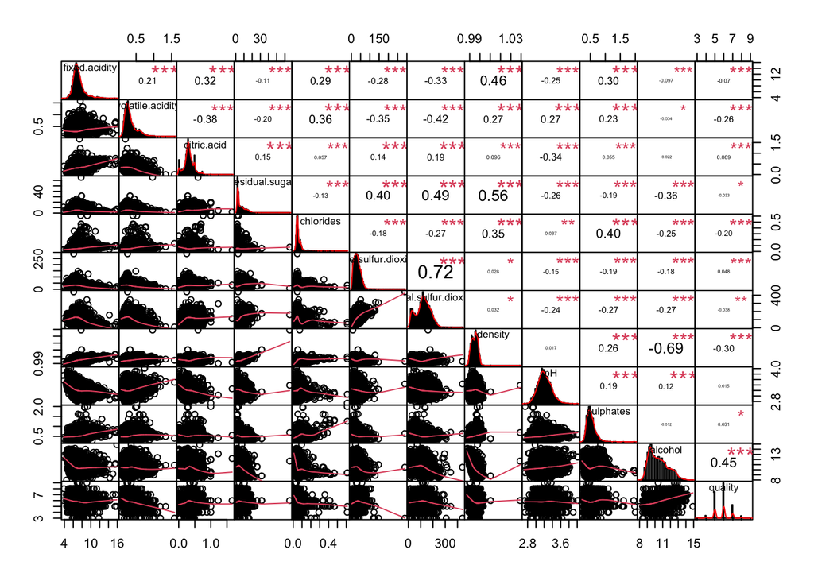

```r
chart.Correlation(training_data[, 1:12], histogram = TRUE, pch = 19)
```

From the above graph, we find that it’s hard to notice a conclusive pattern.

But we still find that the correlation between free.sulfur.dioxide and all.sulfur.dioxide is high, which adhere to our intuition.

Also, we discover that the correlation between quality and alcohol is 0.45, which is the highest compared to other predictors.

```r
model1 = lm(quality ~ free.sulfur.dioxide, data = training_data)
model2 = lm(quality ~ total.sulfur.dioxide, data = training_data)
model3 = lm(quality ~ fixed.acidity, data = training_data)
model4 = lm(quality ~ volatile.acidity, data = training_data)
model5 = lm(quality ~ residual.sugar, data = training_data)
model6 = lm(quality ~ chlorides, data = training_data)
model7 = lm(quality ~ density, data = training_data)
model8 = lm(quality ~ pH, data = training_data)
model9 = lm(quality ~ sulphates, data = training_data)
model10 = lm(quality ~ alcohol, data = training_data)
model11 = lm(quality ~ citric.acid, data = training_data)
```

To compare these models in a more visualized way, we will compare the residual standard error and R-squared of each model to select the best one.

```r
sigma.list = c(summary(model1)$sigma, summary(model2)$sigma, summary(model3)$sigma, summary(model4)$sigma, summary(model5)$sigma, summary(model6)$sigma, summary(model7)$sigma, summary(model8)$sigma, summary(model9)$sigma, summary(model10)$sigma, summary(model11)$sigma)

r.squared.list = c(summary(model1)$r.squared, summary(model2)$r.squared, summary(model3)$r.squared, summary(model4)$r.squared, summary(model5)$r.squared, summary(model6)$r.squared, summary(model7)$r.squared, summary(model8)$r.squared, summary(model9)$r.squared, summary(model10)$r.squared, summary(model11)$r.squared)

(data1 = data.frame(residual.standard.error = sigma.list, R.squared = r.squared.list))
```

```
##    residual.standard.error    R.squared
## 1                0.8748192 0.0022827257
## 2                0.8751883 0.0014406568
## 3                0.8736850 0.0048680830
## 4                0.8447791 0.0696266901
## 5                0.8753413 0.0010913958
## 6                0.8587266 0.0386518165
## 7                0.8350839 0.0908593666
## 8                0.8757221 0.0002221136
## 9                0.8753925 0.0009746232
## 10               0.7825919 0.2015612592
## 11               0.8723517 0.0079030854
```

We find the model uses **quality** as response and **alcohol** as predictor is the best simple linear model, because this model has the highest R-squared and lowest residual standard error.

```r
summary(model10)
```

```
##
## Call:
## lm(formula = quality ~ alcohol, data = training_data)
##
## Residuals:
##     Min      1Q  Median      3Q     Max
## -3.5078 -0.4916 -0.0161  0.5084  3.2134
##
## Coefficients:
##             Estimate Std. Error t value Pr(>|t|)
## (Intercept)  2.37768    0.09558   24.88   <2e-16 ***
## alcohol      0.32778    0.00905   36.22   <2e-16 ***
## ---
## Signif. codes:  0 '***' 0.001 '**' 0.01 '*' 0.05 '.' 0.1 ' ' 1
##
## Residual standard error: 0.7826 on 5197 degrees of freedom
## Multiple R-squared:  0.2016, Adjusted R-squared:  0.2014
## F-statistic:  1312 on 1 and 5197 DF,  p-value: < 2.2e-16
```

We conducted a significance test for this best simple linear regression model and the p-value is extremely closed to 0. Thus, we conclude that this model is significant and **alcohol** is a significant predictor.

## Multiple Linear Regression Model

We would like to build a full addictive model that takes **quality** as response and all the other variables as predictors.

```r
full.add.model = lm(quality ~ ., data = training_data)
summary(full.add.model)
```

```
##
## Call:
## lm(formula = quality ~ ., data = training_data)
##
## Residuals:
##     Min      1Q  Median      3Q     Max
## -3.6366 -0.4692 -0.0434  0.4605  3.0248
##
## Coefficients:
##                        Estimate Std. Error t value Pr(>|t|)
## (Intercept)           9.270e+01  1.552e+01   5.971 2.51e-09 ***
## fixed.acidity         7.238e-02  1.747e-02   4.143 3.48e-05 ***
## volatile.acidity     -1.541e+00  9.140e-02 -16.864  < 2e-16 ***
## citric.acid          -2.542e-02  8.844e-02  -0.287  0.77381
## residual.sugar        5.882e-02  6.564e-03   8.960  < 2e-16 ***
## chlorides            -7.878e-01  3.596e-01  -2.191  0.02852 *
## free.sulfur.dioxide   4.021e-03  8.497e-04   4.733 2.27e-06 ***
## total.sulfur.dioxide -1.057e-03  3.628e-04  -2.913  0.00359 **
## density              -9.166e+01  1.575e+01  -5.821 6.20e-09 ***
## pH                    4.323e-01  1.014e-01   4.264 2.04e-05 ***
## sulphates             6.827e-01  8.435e-02   8.094 7.15e-16 ***
## alcohol               2.434e-01  1.994e-02  12.202  < 2e-16 ***
## typewhite            -3.801e-01  6.341e-02  -5.994 2.18e-09 ***
## ---
## Signif. codes:  0 '***' 0.001 '**' 0.01 '*' 0.05 '.' 0.1 ' ' 1
##
## Residual standard error: 0.7344 on 5186 degrees of freedom
## Multiple R-squared:  0.2983, Adjusted R-squared:  0.2967
## F-statistic: 183.7 on 12 and 5186 DF,  p-value: < 2.2e-16
```

The p-value of the model is less than 0.05. Therefore, we reject the null hypothesis and conclude that at least one of the predictors is significant in explaining the response. We would like to compare the best simple linear regression model and this full addictive model to find the better of these two models.

```r
model_alcohol = model10
anova(model_alcohol, full.add.model)
```

```
## Analysis of Variance Table
##
## Model 1: quality ~ alcohol
## Model 2: quality ~ fixed.acidity + volatile.acidity + citric.acid + residual.sugar +
##     chlorides + free.sulfur.dioxide + total.sulfur.dioxide +
##     density + pH + sulphates + alcohol + type
##   Res.Df    RSS Df Sum of Sq      F    Pr(>F)
## 1   5197 3182.9
## 2   5186 2797.2 11    385.65 64.999 < 2.2e-16 ***
## ---
## Signif. codes:  0 '***' 0.001 '**' 0.01 '*' 0.05 '.' 0.1 ' ' 1
```

By comparing the **model_alcohol** and **full.add.model**, we notice that the p-value is extremely closed to 0. We conclude that we prefer the **full.add.model**, which is the full addictive model. However, the best model is not necessary to include all the predictors. We conduct a significance test for the full model (above) and we find that although the residual standard error is very small, the adjusted R-squared is just 0.2967. We can state that the full addictive model is probably not the best model.

### Forward / Backward / Exhaustive Selection with AIC & BIC

We use backward selection with AIC and BIC to construct two new models and we will also use exhaustive search with best AIC and BIC to build a number of models and select the best model among these models.

```r
# Backward Search with AIC
wine_mod_back_aic = step(full.add.model, direction = "backward", trace = 0)
```

```r
# Backward Search with BIC
n = length(resid(full.add.model))
wine_mod_back_bic = step(full.add.model, direction = "backward", trace = 0, k = log(n))
```

```r
# Forward Search with AIC
full.add.model.start = lm(quality ~ 1, data = training_data)
wine_mod_forw_aic = step(full.add.model.start, scope = quality ~ fixed.acidity + volatile.acidity + citric.acid + residual.sugar + chlorides + free.sulfur.dioxide + total.sulfur.dioxide + density + pH + sulphates + alcohol + type, direction = "forward", trace = 0)
```

```r
# Forward Selection with BIC
wine_mod_forw_bic = step(full.add.model.start, scope = quality ~ fixed.acidity + volatile.acidity + citric.acid + residual.sugar + chlorides + free.sulfur.dioxide + total.sulfur.dioxide + density + pH + sulphates + alcohol + type, direction = "forward", k = log(n), trace = 0)
```

```r
# Exhaustive Search
all_wine_mod = summary(regsubsets(quality ~ ., data = training_data))
best_r2_ind = which.max(all_wine_mod$adjr2)
```

```r
# Exhaustive search with best AIC
p = length(coef(full.add.model))
n = length(resid(full.add.model))
best_aic = n * log(all_wine_mod$rss / n) + 2 * (2:p)
best_aic_ind = which.min(best_aic)
all_wine_mod$which[best_aic_ind,]
```

```
##          (Intercept)        fixed.acidity     volatile.acidity
##                 TRUE                 TRUE                 TRUE
##          citric.acid       residual.sugar            chlorides
##                FALSE                 TRUE                FALSE
##  free.sulfur.dioxide total.sulfur.dioxide              density
##                FALSE                FALSE                 TRUE
##                   pH            sulphates              alcohol
##                 TRUE                 TRUE                 TRUE
##            typewhite
##                 TRUE
```

The exhaustive search model with AIC contains the variables fixed.acidity, volatile.acidity, residual.sugar, density, pH, sulphates, alcohol, and type.

```r
# Exhaustive search with best BIC
best_bic = n * log(all_wine_mod$rss / n) + log(n) * (2:p)
best_bic_ind = which.min(best_bic)
all_wine_mod$which[best_bic_ind,]
```

```
##          (Intercept)        fixed.acidity     volatile.acidity
##                 TRUE                 TRUE                 TRUE
##          citric.acid       residual.sugar            chlorides
##                FALSE                 TRUE                FALSE
##  free.sulfur.dioxide total.sulfur.dioxide              density
##                FALSE                FALSE                 TRUE
##                   pH            sulphates              alcohol
##                 TRUE                 TRUE                 TRUE
##            typewhite
##                 TRUE
```

By comparing the predictors selected by an exhaustive search, best AIC, and best BIC, we have found that they all select the same predictors, which include **fixed.acidity**, **volatile.acidity**, **residual.sugar**, **density**, **pH**, **sulphates**, **alcohol**, and **type**.

```r
# model selected by the exhaustive search
wine_mod_exhaustive = lm(quality ~ fixed.acidity + volatile.acidity  + residual.sugar + density + pH + sulphates + alcohol + type, data = training_data)
```

We will fit some more complex models.

We want to start with a big model and use backwards AIC to reduce the number of parameters.

Before we generate a big model, we want to compare and get the best multiple linear regression model.

```r
# additive model comparison
calc_loocv_rmse = function(model) {
  sqrt(mean((resid(model) / (1 - hatvalues(model))) ^ 2))
}
rmse = c(calc_loocv_rmse(full.add.model), calc_loocv_rmse(wine_mod_back_aic), calc_loocv_rmse(wine_mod_back_bic), calc_loocv_rmse(wine_mod_forw_aic), calc_loocv_rmse(wine_mod_forw_bic), calc_loocv_rmse(wine_mod_exhaustive))
r.square = c(summary(full.add.model)$adj.r.squared, summary(wine_mod_back_aic)$adj.r.squared, summary(wine_mod_back_bic)$adj.r.squared, summary(wine_mod_forw_aic)$adj.r.squared, summary(wine_mod_forw_bic)$adj.r.squared, summary(wine_mod_exhaustive)$adj.r.squared)
cbind(rmse, r.square)
```

```
##           rmse  r.square
## [1,] 0.7358895 0.2966797
## [2,] 0.7357624 0.2968041
## [3,] 0.7365044 0.2952283
## [4,] 0.7357624 0.2968041
## [5,] 0.7367241 0.2942325
## [6,] 0.7370047 0.2935492
```

After comparing the adjusted R-squared and LOOCV RMSE, we notice that the models selected by the forward and backward selection with AIC, **wine_mod_back_aic** and **wine_mod_forw_aic**, are identical because they have the same predictors, R-squared, and LOOCV RMSE. **wine_mod_back_aic** has the lowest LOOCV RMSE and biggest adjusted R-squared. However, its number of predictors are more than **wine_mod_exhaustive**.

```r
cbind(length(coef(wine_mod_back_aic)),length(coef(wine_mod_exhaustive)))
```

```
##      [,1] [,2]
## [1,]   12    9
```

And we notice that the LOOCV RMSE and R-squared of these two models are very closed. Thus, we decide to adopt the one with less predictors as the best model so far, **wine_mod_exhaustive**.

### Quadratic Model

In the **wine_mod_exhaustive** model, there are only first-order terms. Next, we will consider polynomial terms. We will put the predictors of **wine_mod_exhaustive** into quadratic forms and compare the new model with **wine_mod_exhaustive**.

```r
coef(wine_mod_exhaustive) # predictors of wine_mod_exhaustive
```

```
##      (Intercept)    fixed.acidity volatile.acidity   residual.sugar
##     106.10106621       0.07794695      -1.61022310       0.06548462
##          density               pH        sulphates          alcohol
##    -105.34292710       0.50507064       0.64234589       0.23740461
##        typewhite
##      -0.43658381
```

```r
wine_mod_exhaustive_quad = lm(quality ~ . + I(fixed.acidity ^ 2) + I(volatile.acidity ^ 2) + I(residual.sugar ^ 2) + I(density ^ 2) + I(pH ^ 2) + I(sulphates ^ 2) + I(alcohol ^ 2), data = training_data)
summary(wine_mod_exhaustive_quad)
```

```
##
## Call:
## lm(formula = quality ~ . + I(fixed.acidity^2) + I(volatile.acidity^2) +
##     I(residual.sugar^2) + I(density^2) + I(pH^2) + I(sulphates^2) +
##     I(alcohol^2), data = training_data)
##
## Residuals:
##     Min      1Q  Median      3Q     Max
## -3.4190 -0.4744 -0.0319  0.4516  3.0135
##
## Coefficients:
##                         Estimate Std. Error t value Pr(>|t|)
## (Intercept)            6.949e+03  9.843e+02   7.059 1.89e-12 ***
## fixed.acidity          1.652e-01  5.725e-02   2.887 0.003910 **
## volatile.acidity      -2.308e+00  2.514e-01  -9.182  < 2e-16 ***
## citric.acid           -6.281e-02  8.831e-02  -0.711 0.476985
## residual.sugar         1.188e-01  1.128e-02  10.534  < 2e-16 ***
## chlorides             -5.878e-01  3.675e-01  -1.599 0.109832
## free.sulfur.dioxide    3.274e-03  8.526e-04   3.840 0.000124 ***
## total.sulfur.dioxide  -1.030e-03  3.685e-04  -2.794 0.005218 **
## density               -1.386e+04  1.974e+03  -7.019 2.52e-12 ***
## pH                     5.296e+00  1.736e+00   3.051 0.002291 **
## sulphates              1.328e+00  2.457e-01   5.402 6.88e-08 ***
## alcohol               -2.303e-01  1.566e-01  -1.471 0.141484
## typewhite             -4.864e-01  6.747e-02  -7.208 6.48e-13 ***
## I(fixed.acidity^2)    -4.724e-03  3.207e-03  -1.473 0.140907
## I(volatile.acidity^2)  6.964e-01  2.470e-01   2.820 0.004821 **
## I(residual.sugar^2)   -3.243e-03  5.226e-04  -6.205 5.88e-10 ***
## I(density^2)           6.902e+03  9.898e+02   6.973 3.48e-12 ***
## I(pH^2)               -7.329e-01  2.678e-01  -2.736 0.006232 **
## I(sulphates^2)        -4.183e-01  1.670e-01  -2.505 0.012274 *
## I(alcohol^2)           1.911e-02  7.219e-03   2.647 0.008145 **
## ---
## Signif. codes:  0 '***' 0.001 '**' 0.01 '*' 0.05 '.' 0.1 ' ' 1
##
## Residual standard error: 0.7289 on 5179 degrees of freedom
## Multiple R-squared:  0.3098, Adjusted R-squared:  0.3072
## F-statistic: 122.3 on 19 and 5179 DF,  p-value: < 2.2e-16
```

It is clear that not all of the predictors are significant. Thus, we will use backward AIC selection to create a new model.

```r
wine_mod_exhaustive_quad_aic = step(wine_mod_exhaustive_quad, direction = "backward", trace = 0)
```

```r
anova(wine_mod_exhaustive_quad_aic, wine_mod_exhaustive_quad)
```

```
## Analysis of Variance Table
##
## Model 1: quality ~ fixed.acidity + volatile.acidity + residual.sugar +
##     chlorides + free.sulfur.dioxide + total.sulfur.dioxide +
##     density + pH + sulphates + alcohol + type + I(fixed.acidity^2) +
##     I(volatile.acidity^2) + I(residual.sugar^2) + I(density^2) +
##     I(pH^2) + I(sulphates^2) + I(alcohol^2)
## Model 2: quality ~ fixed.acidity + volatile.acidity + citric.acid + residual.sugar +
##     chlorides + free.sulfur.dioxide + total.sulfur.dioxide +
##     density + pH + sulphates + alcohol + type + I(fixed.acidity^2) +
##     I(volatile.acidity^2) + I(residual.sugar^2) + I(density^2) +
##     I(pH^2) + I(sulphates^2) + I(alcohol^2)
##   Res.Df    RSS Df Sum of Sq      F Pr(>F)
## 1   5180 2751.8
## 2   5179 2751.5  1   0.26873 0.5058  0.477
```

The p-value, 0.477, indicates that we will prefer the smaller model, **wine_mod_exhaustive_quad_aic**.

### Interaction Model

```r
coef(wine_mod_exhaustive)
```

```
##      (Intercept)    fixed.acidity volatile.acidity   residual.sugar
##     106.10106621       0.07794695      -1.61022310       0.06548462
##          density               pH        sulphates          alcohol
##    -105.34292710       0.50507064       0.64234589       0.23740461
##        typewhite
##      -0.43658381
```

The **wine_mod_exhaustive** model contains **fixed.acidity**, **volatile.acidity**, **residual.sugar**, **density**, **pH**, **sulphates**, **alcohol**, and **type** as predictors. We will consider the two-way interactions between these predictors and add these terms to **wine_mod_exhaustive_quad_aic** to construct a new model.

```r
two_way_interaction_model = lm(quality ~ (fixed.acidity + volatile.acidity + residual.sugar + density + pH + sulphates + alcohol + type)^2 + I(fixed.acidity^2) + I(volatile.acidity^2) + I(residual.sugar^2) + I(density^2) + I(pH^2) + I(sulphates^2) + I(alcohol^2), data = training_data)
summary(two_way_interaction_model)
```

```
##
## Call:
## lm(formula = quality ~ (fixed.acidity + volatile.acidity + residual.sugar +
##     density + pH + sulphates + alcohol + type)^2 + I(fixed.acidity^2) +
##     I(volatile.acidity^2) + I(residual.sugar^2) + I(density^2) +
##     I(pH^2) + I(sulphates^2) + I(alcohol^2), data = training_data)
##
## Residuals:
##     Min      1Q  Median      3Q     Max
## -3.5454 -0.4759 -0.0318  0.4440  3.0820
##
## Coefficients:
##                                   Estimate Std. Error t value Pr(>|t|)
## (Intercept)                     -1.195e+04  1.002e+04  -1.192  0.23323
## fixed.acidity                   -3.607e+01  1.957e+01  -1.843  0.06541 .
## volatile.acidity                -5.907e+01  1.142e+02  -0.517  0.60486
## residual.sugar                  -2.650e+01  1.055e+01  -2.512  0.01205 *
## density                          2.324e+04  2.044e+04   1.137  0.25555
## pH                               1.300e+02  1.504e+02   0.864  0.38739
## sulphates                        2.104e+02  1.266e+02   1.662  0.09666 .
## alcohol                          5.911e+01  2.210e+01   2.674  0.00751 **
## typewhite                        3.120e+02  6.767e+01   4.611 4.11e-06 ***
## I(fixed.acidity^2)              -3.416e-02  1.175e-02  -2.906  0.00367 **
## I(volatile.acidity^2)           -3.225e-01  3.509e-01  -0.919  0.35805
## I(residual.sugar^2)             -1.133e-02  2.625e-03  -4.317 1.61e-05 ***
## I(density^2)                    -1.127e+04  1.042e+04  -1.081  0.27975
## I(pH^2)                          2.617e-01  6.262e-01   0.418  0.67610
## I(sulphates^2)                  -5.072e-01  3.085e-01  -1.644  0.10022
## I(alcohol^2)                    -3.182e-02  1.875e-02  -1.697  0.08973 .
## fixed.acidity:volatile.acidity  -8.442e-02  1.343e-01  -0.629  0.52961
## fixed.acidity:residual.sugar    -2.344e-02  1.014e-02  -2.310  0.02092 *
## fixed.acidity:density            3.546e+01  1.997e+01   1.776  0.07583 .
## fixed.acidity:pH                 2.084e-01  1.668e-01   1.249  0.21156
## fixed.acidity:sulphates          2.908e-01  1.281e-01   2.271  0.02320 *
## fixed.acidity:alcohol            5.653e-02  2.464e-02   2.294  0.02181 *
## fixed.acidity:typewhite          2.119e-01  7.535e-02   2.812  0.00494 **
## volatile.acidity:residual.sugar -4.695e-02  5.055e-02  -0.929  0.35304
## volatile.acidity:density         5.382e+01  1.159e+02   0.465  0.64231
## volatile.acidity:pH              5.864e-01  8.362e-01   0.701  0.48317
## volatile.acidity:sulphates      -5.373e-01  6.274e-01  -0.856  0.39182
```

[output cut: 8 more lines]

```
## density:sulphates               -2.207e+02  1.283e+02  -1.720  0.08551 .
## density:alcohol                 -5.919e+01  2.250e+01  -2.631  0.00854 **
## density:typewhite               -3.194e+02  6.873e+01  -4.647 3.46e-06 ***
## pH:sulphates                     3.261e+00  7.457e-01   4.373 1.25e-05 ***
## pH:alcohol                       4.763e-02  2.029e-01   0.235  0.81443
## pH:typewhite                     2.271e+00  5.002e-01   4.541 5.72e-06 ***
## sulphates:alcohol               -1.308e-01  1.542e-01  -0.848  0.39644
## sulphates:typewhite             -6.943e-01  4.389e-01  -1.582  0.11375
## alcohol:typewhite               -3.351e-01  8.503e-02  -3.941 8.23e-05 ***
## ---
## Signif. codes:  0 '***' 0.001 '**' 0.01 '*' 0.05 '.' 0.1 ' ' 1
##
## Residual standard error: 0.7138 on 5155 degrees of freedom
## Multiple R-squared:  0.3411, Adjusted R-squared:  0.3356
## F-statistic: 62.05 on 43 and 5155 DF,  p-value: < 2.2e-16
```

It looks like there are many redundant insignificant terms in this model.

We then use backward selection with AIC to create a new model.

```r
int_aic = step(two_way_interaction_model, direction = "backward", trace = 0)
```

We then want to compare these two models to find out the better one.

```r
anova(int_aic, two_way_interaction_model)
```

```
## Analysis of Variance Table
##
## Model 1: quality ~ fixed.acidity + volatile.acidity + residual.sugar +
##     density + pH + sulphates + alcohol + type + I(fixed.acidity^2) +
##     I(residual.sugar^2) + I(sulphates^2) + I(alcohol^2) + fixed.acidity:residual.sugar +
##     fixed.acidity:density + fixed.acidity:pH + fixed.acidity:sulphates +
##     fixed.acidity:alcohol + fixed.acidity:type + volatile.acidity:pH +
##     volatile.acidity:alcohol + volatile.acidity:type + residual.sugar:density +
##     residual.sugar:pH + residual.sugar:alcohol + residual.sugar:type +
##     density:pH + density:sulphates + density:alcohol + density:type +
##     pH:sulphates + pH:type + sulphates:type + alcohol:type
## Model 2: quality ~ (fixed.acidity + volatile.acidity + residual.sugar +
##     density + pH + sulphates + alcohol + type)^2 + I(fixed.acidity^2) +
##     I(volatile.acidity^2) + I(residual.sugar^2) + I(density^2) +
##     I(pH^2) + I(sulphates^2) + I(alcohol^2)
##   Res.Df    RSS Df Sum of Sq      F Pr(>F)
## 1   5165 2630.0
## 2   5155 2626.8 10    3.2648 0.6407 0.7799
```

After the comparison, the large p-value, 0.7799, suggests that we prefer the model **int_aic**.

## Classification

Given the nature of the response variable, we may expect that linear regression model will not perform very well in this case.

Therefore, we’d like to consider some classification methods.

```r
t = as.data.frame(table(training_data$quality))
t
```

```
##   Var1 Freq
## 1    3   26
## 2    4  175
## 3    5 1707
## 4    6 2269
## 5    7  863
## 6    8  155
## 7    9    4
```

```r
count(training_data, "quality")
```

```
##   "quality"    n
## 1   quality 5199
```

From above, we see that the levels in “quality” are unevenly distributed.

Therefore, some classification methods might not perform well on the quality levels with lower frequency.

### Support Vector Machine

```r
training_data$quality = as.factor(training_data$quality)
svm_model = svm(quality ~., data = training_data, method = "C-classification", kernal = "radial", gamma = 0.9, cost = 15)
summary(svm_model)
```

```
##
## Call:
## svm(formula = quality ~ ., data = training_data, method = "C-classification",
##     kernal = "radial", gamma = 0.9, cost = 15)
##
##
## Parameters:
##    SVM-Type:  C-classification
##  SVM-Kernel:  radial
##        cost:  15
##
## Number of Support Vectors:  4450
##
##  ( 1408 1924 768 175 145 26 4 )
##
##
## Number of Classes:  7
##
## Levels:
##  3 4 5 6 7 8 9
```

We use the default method and kernal in this case and the model finds 4450 support vectors distributed across the classes.

# Results

We would like to use the adjusted R-squared, LOOCV RMSE, AIC value, and number of terms of models to the testing data as standards to select the best model among the linear regression and interaction models.

```r
adjusted.r.squared = c(summary(int_aic)$adj.r.squared, summary(two_way_interaction_model)$adj.r.squared, summary(wine_mod_exhaustive_quad_aic)$adj.r.squared, summary(wine_mod_exhaustive_quad)$adj.r.squared, summary(wine_mod_exhaustive)$adj.r.squared, summary(full.add.model)$adj.r.squared, summary(wine_mod_back_aic)$adj.r.squared, summary(wine_mod_back_bic)$adj.r.squared, summary(wine_mod_forw_aic)$adj.r.squared, summary(wine_mod_forw_bic)$adj.r.squared, summary(model_alcohol)$adj.r.squared)

rmse = c(calc_loocv_rmse(int_aic), calc_loocv_rmse(two_way_interaction_model), calc_loocv_rmse(wine_mod_exhaustive_quad_aic), calc_loocv_rmse(wine_mod_exhaustive_quad), calc_loocv_rmse(wine_mod_exhaustive), calc_loocv_rmse(full.add.model), calc_loocv_rmse(wine_mod_back_aic), calc_loocv_rmse(wine_mod_back_bic), calc_loocv_rmse(wine_mod_forw_aic), calc_loocv_rmse(wine_mod_forw_bic), calc_loocv_rmse(model_alcohol))

aic = c(extractAIC(int_aic)[2], extractAIC(two_way_interaction_model)[2], extractAIC(wine_mod_exhaustive_quad_aic)[2], extractAIC(wine_mod_exhaustive_quad)[2], extractAIC(wine_mod_exhaustive)[2], extractAIC(full.add.model)[2], extractAIC(wine_mod_back_aic)[2], extractAIC(wine_mod_back_bic)[2], extractAIC(wine_mod_forw_aic)[2], extractAIC(wine_mod_forw_bic)[2], extractAIC(model_alcohol)[2])

term_number = c(length(coef(int_aic)), length(coef(two_way_interaction_model)), length(coef(wine_mod_exhaustive_quad_aic)), length(coef(wine_mod_exhaustive_quad)), length(coef(wine_mod_exhaustive)), length(coef(full.add.model)), length(coef(wine_mod_back_aic)), length(coef(wine_mod_back_bic)), length(coef(wine_mod_forw_aic)), length(coef(wine_mod_forw_bic)), length(coef(model_alcohol)))

models = c("int_aic", "two_way_interaction_model", "wine_mod_exhaustive_quad_aic", "wine_mod_exhaustive_quad", "wine_mod_exhaustive", "full.add.model", "wine_mod_back_aic", "wine_mod_back_bic", "wine_mod_forw_aic", "wine_mod_forw_bic", "model_alcohol")

cbind(models, adjusted.r.squared, rmse, aic, term_number)
```

```
##       models                         adjusted.r.squared  rmse
##  [1,] "int_aic"                      "0.336039638164488" "0.727112043706278"
##  [2,] "two_way_interaction_model"    "0.335577447011794" "0.725349662708012"
##  [3,] "wine_mod_exhaustive_quad_aic" "0.307313697589721" "0.733172388408735"
##  [4,] "wine_mod_exhaustive_quad"     "0.307247608203642" "0.733264149215295"
##  [5,] "wine_mod_exhaustive"          "0.293549209256594" "0.737004712105735"
##  [6,] "full.add.model"               "0.296679711246653" "0.735889487728109"
##  [7,] "wine_mod_back_aic"            "0.296804103317103" "0.735762443531666"
##  [8,] "wine_mod_back_bic"            "0.295228346263653" "0.736504402113814"
##  [9,] "wine_mod_forw_aic"            "0.296804103317103" "0.735762443531666"
## [10,] "wine_mod_forw_bic"            "0.29423246611376"  "0.736724106369866"
## [11,] "model_alcohol"                "0.201407624695452" "0.782752251808109"
##       aic                 term_number
##  [1,] "-3474.9997214359"  "34"
##  [2,] "-3461.45747580488" "44"
##  [3,] "-3269.72036629942" "19"
##  [4,] "-3268.22811682097" "20"
##  [5,] "-3177.39619066473" "9"
##  [6,] "-3196.49424564166" "13"
##  [7,] "-3198.41143302408" "12"
##  [8,] "-3188.77004308102" "10"
##  [9,] "-3198.41143302408" "12"
## [10,] "-3181.4287628032"  "10"
## [11,] "-2547.00645632046" "2"
```

```r
accur <- function(list1, list2) {
  if (length(list1) != length(list2)) {
    stop()
  }
  list1 = round(list1,0)
  list2 = round(list2,0)
  n = length(list1)
  count = 0
  for (i in 1:n) {
    if (list1[i] == list2[i]) {
      count = count + 1
    }
  }
  accuracy = count/n
  return(accuracy)
}

prediction1 = predict(int_aic, testing_data)
prediction2 = predict(wine_mod_exhaustive_quad_aic, testing_data)
accuracy1 = accur(testing_data$quality, prediction1)
accuracy2 = accur(testing_data$quality, prediction2)
cbind(accuracy1, accuracy2)
```

```
##      accuracy1 accuracy2
## [1,]  0.550077 0.5354391
```

The **int_aic** has a higher accuracy than **wine_mod_exhaustive_quad_aic**. We prefer **int_aic** as the best model among the linear regression and interaction models. We also would like to compare the accuracy between classification method and **int_aic**, specifically the support vector machine method.

```r
prediction3 = predict(svm_model, testing_data)
confusion_matrix = table(testing_data$quality, prediction3)
confusion_matrix
```

```
##    prediction3
##       3   4   5   6   7   8   9
##   3   0   0   1   3   0   0   0
##   4   0   5  19  15   2   0   0
##   5   0   4 302 117   8   0   0
##   6   0   2  94 424  40   7   0
##   7   0   1  18  77 116   4   0
##   8   0   0   2  10  13  13   0
##   9   0   0   0   0   1   0   0
```

```r
correctPred = 0
for (i in 1:nrow(confusion_matrix)) {
  correctPred = correctPred + confusion_matrix[i, i]
}
accuracy = correctPred / nrow(testing_data)
accuracy
```

```
## [1] 0.6625578
```

From the above confusion matrix, we calculate that the accuracy is 0.663, which is larger than the accuracy of **int_aic**.

We conclude that SVM and **int_aic** are the best two final models.

# Discussion

Different from the traditional, relying on human tasting to judge the quality of wines, our analysis quantifies the characteristics of wine and utilizes statistical models to draw conclusions. In today’s wine market, there are so many varieties of wine that consumers often feel unable to start. Our models and result provide customers with a reference.

# Appendix

## Accuracy table

Here we are going to show the prediction accuracy of all models discussed above.

```r
all_models = c("int_aic", "two_way_interaction_model", "wine_mod_exhaustive_quad_aic", "wine_mod_exhaustive_quad", "wine_mod_exhaustive", "full.add.model", "wine_mod_back_aic", "wine_mod_back_bic", "wine_mod_forw_aic", "wine_mod_forw_bic", "model_alcohol", "SVM")
all_accuracy = c(accur(testing_data$quality, predict(int_aic, testing_data)), accur(testing_data$quality, predict(two_way_interaction_model, testing_data)), accur(testing_data$quality, predict(wine_mod_exhaustive_quad_aic, testing_data)), accur(testing_data$quality, predict(wine_mod_exhaustive_quad, testing_data)), accur(testing_data$quality, predict(wine_mod_exhaustive, testing_data)), accur(testing_data$quality, predict(full.add.model, testing_data)), accur(testing_data$quality, predict(wine_mod_back_aic, testing_data)), accur(testing_data$quality, predict(wine_mod_back_bic, testing_data)), accur(testing_data$quality, predict(wine_mod_forw_aic, testing_data)), accur(testing_data$quality, predict(wine_mod_forw_bic, testing_data)), accur(testing_data$quality, predict(model_alcohol, testing_data)),
accuracy)
all_accuracy = cbind(all_models, all_accuracy)
all_accuracy
```

```
##       all_models                     all_accuracy
##  [1,] "int_aic"                      "0.550077041602465"
##  [2,] "two_way_interaction_model"    "0.547765793528505"
##  [3,] "wine_mod_exhaustive_quad_aic" "0.535439137134052"
##  [4,] "wine_mod_exhaustive_quad"     "0.539291217257319"
##  [5,] "wine_mod_exhaustive"          "0.533898305084746"
##  [6,] "full.add.model"               "0.533898305084746"
##  [7,] "wine_mod_back_aic"            "0.531587057010786"
##  [8,] "wine_mod_back_bic"            "0.536979969183359"
##  [9,] "wine_mod_forw_aic"            "0.531587057010786"
## [10,] "wine_mod_forw_bic"            "0.541602465331279"
## [11,] "model_alcohol"                "0.489984591679507"
## [12,] "SVM"                          "0.662557781201849"
```

## Group Number

Eric Lu (cunyuan2)  
Andy Luo (yuhuail2)  
Ted Chen (jundong2)  
Dali Su (dalisu2)